# Pulse of Melbourne

Pedestrian rhythms, recovery and unusual activity.

Authors

Richa Anghan

Zhuo Zhang

Nishta Bollavaram

# Abstract

Melbourne’s pedestrian activity reflects how people use the city at different times and places. This project examines recurring patterns, changes since the COVID-19 pandemic, differences between locations, and unusually busy or quiet days. It uses approximately 7.56 million hourly records from the City of Melbourne’s pedestrian counting system, covering May 2009 to October 2026, alongside event permits, weather records and public-holiday information.

The analysis compared the same locations over time, grouped locations with similar weekday and weekend patterns, and identified dates when activity differed substantially from its expected level. Across 27 selected monitoring locations, typical recorded daily counts were 28.5% lower during 2023–2025 than during 2017–2019, although the timing of daily activity remained broadly similar. Locations showed different degrees of recovery and two broad patterns: sharper weekday peaks, and broader daytime activity with relatively stronger weekends. Selected unusually busy dates coincided with event permits, while substantial declines were more frequent on public holidays and in heavier-rain categories.

These findings show that changes in pedestrian activity differ across times and locations. They can inform transport, public-space and event planning, while highlighting the importance of sensor coverage and recording conventions when interpreting change. The results describe the selected monitored locations rather than all pedestrian movement across Melbourne.

# 1 Introduction

## 1.1 Understanding Melbourne’s Pedestrian Pulse

On 22 February 2014, pedestrian activity near Flinders Street and Elizabeth Street showed an unusual pattern as seen in Figure 1. Compared with other Saturdays in February, pedestrian counts remained noticeably higher, particularly into the evening. What would normally have been a relatively quiet period instead recorded sustained activity. This observation raised a broader question: was this an isolated occurrence at one location, or part of a larger change in how people were moving through Melbourne?

[interactive chart not shown]

Figure 1: Hourly recorded pedestrian counts at Flinders Street–Elizabeth Street (East) on 22 February 2014, compared with the median count at each hour on the other Saturdays in February 2014.

Melbourne’s streets serve different purposes throughout the day. Morning activity often reflects commuting, while shopping, leisure and other activities contribute to movement during the afternoon, evenings and weekends. These patterns can also vary across locations, seasons and years. Major disruptions, public events and weather conditions may further influence how frequently and when people move through the city.

The City of Melbourne measures pedestrian activity using sensors at individual locations across central Melbourne and surrounding activity areas. Each sensor records the number of pedestrian passages during an hour. Someone passing more than once may be counted repeatedly, so these records measure activity at monitored locations rather than the number of different people or every walking trip across the city.

Understanding these variations is important for urban planning and decision-making. Information about pedestrian activity can help identify busy periods and locations, support transport and infrastructure planning, and inform how public spaces are managed during major events. However, identifying meaningful changes requires more than simply comparing pedestrian counts. Activity recorded at a particular location may vary because of changes in travel behaviour, but also because of differences in sensor coverage, installation dates or data availability.

The City of Melbourne’s pedestrian counting system provides an opportunity to investigate these patterns using observations collected over an extended period. By examining both the timing and geographical distribution of pedestrian activity, this project explores how Melbourne’s movement follows familiar rhythms, how these rhythms have evolved, and when they depart from their usual patterns.

## 1.2 Research Aim and Objectives

The primary aim of this project is to investigate **how pedestrian activity across Melbourne varies over time and space, how it has changed over the years, and which circumstances are associated with unusually high or low activity**.

In line with the original project brief, the analysis addresses four related questions:

1. **What are Melbourne’s typical pedestrian rhythms?** We investigate hourly, daily, weekly, monthly and seasonal variations to identify recurring patterns in pedestrian activity.
2. **How has pedestrian activity changed over time?** We examine long-term trends, the disruption associated with COVID-19, and differences between pre-pandemic and more recent periods.
3. **How does pedestrian activity vary across locations?** We investigate differences in pedestrian volumes and whether locations exhibit similar patterns of activity throughout weekdays and weekends.
4. **When does pedestrian activity depart from its usual patterns?** We identify unusually busy and quiet days and examine their associations with major events, rainfall and public holidays.

Together, these questions allow the project to move beyond identifying where and when pedestrian counts are highest. They provide a framework for understanding how the city’s movement patterns differ, how they have evolved, and what may be associated with substantial changes.

This project brings together historical records, recent online data and additional files supplied by the City of Melbourne. It investigates conflicting counts, reconstructs unusable hour labels and accounts for changing coverage when comparing locations and periods. Combining these records with event, weather and holiday information connects the city’s regular pedestrian patterns with changes over time and unusually busy or quiet days.

**How to read the results**

Table 1: Key terms used in the report.

| Term | Meaning |
| --- | --- |
| Recorded pedestrian count | The number of passages recorded by a sensor. This is not necessarily the number of different people, because someone passing more than once may be counted repeatedly. |
| Sensor-hour / sensor-day | A sensor-hour is one location's observation for one hour. A sensor-day combines its recorded hourly counts for one date. |
| Median | The middle value after observations are ordered from lowest to highest, or the average of the two middle values when there is an even number. |
| Activity index | A comparison scale where 100 represents average activity within that year's daily or weekly profile. An index of 120 means 20% above that reference, while 80 means 20% below it. |
| Baseline | The reference level used for comparison, such as earlier activity at the same location or expected activity on similar weekdays. |
| Uplift | The percentage increase above expected activity. For example, 1,500 recorded passages compared with 1,000 expected passages represents a 50% uplift. |

# 2 Data Sources and Preparation

## 2.1 Data Sources

This project uses the City of Melbourne’s Pedestrian Counting System as its primary dataset, supplemented by sensor-location records, event permits, historical weather observations and Victorian public-holiday information. Together, these sources support the investigation of Melbourne’s pedestrian activity across time and space, including changes associated with major disruptions and unusual activity.

The pedestrian data combine historical CSV files with records retrieved through the City of Melbourne’s online data service, known as an API (City of Melbourne, n.d.c). The City also supplied annual extracts of records, referred to as snapshots, for 2022–2025 to address gaps in publicly accessible data. After combining and cleaning these sources, the dataset contained **7,566,998 hourly observations**, covering **May 2009 to October 2026**.

Supplementary datasets were used to provide geographical and contextual information. The City of Melbourne’s sensor-location dataset provided coordinates and installation information for spatial analysis (City of Melbourne, n.d.b). Event permit records from the City of Melbourne were used to investigate whether unusual pedestrian activity coincided with permitted events (City of Melbourne, n.d.a). Historical weather data from Open-Meteo provided rainfall and other weather observations (Open-Meteo, n.d.). Victorian public holidays were identified from the locally stored calendar file `important_dates_august_2026.csv`, retaining records classified as public holidays. The file includes year-specific Business Victoria source links. The holiday analysis uses dates from 2019, 2023–2025 and 1 January–6 September 2026, rather than relying only on the 2026 holiday calendar (Department of Government Services 2026).

Because the pedestrian sensor network expanded over time and individual sensors did not always report continuously, coverage varied across locations and years. These differences were considered during data preparation and when selecting observations for subsequent analyses.

## 2.2 Data Integration and Preparation

Before comparing pedestrian activity, the different files needed to be made consistent. This involved giving equivalent information the same format, correcting unusable hour labels, comparing records that appeared in more than one source, and selecting which source to retain. The combined records were then checked for duplicates, missing information and invalid values.

### 2.2.1 Standardising the Pedestrian Records

Each observation was organised around four pieces of information: the monitoring location (`location_id`), date (`sensing_date`), hour (`hourday`) and recorded pedestrian count (`pedestrian_count`). Using the same structure allowed historical and recent files to be combined.

Dates were converted to a common format. Location identifiers were used to connect records across periods because some location names had changed even though they referred to the same monitoring site.

The combination of location, date and hour identified one observation. This allowed records describing the same observation to be compared across sources and prevented duplicate records from being counted more than once.

### 2.2.2 Identifying and Correcting Data Inconsistencies

During data preparation, inconsistencies were identified in the historical hourly records. In particular, some sensor-day groups contained 24 observations but only one distinct hour label, preventing the observations from being directly assigned to their correct hours.

A total of 510 sensor-day groups exhibited this issue, representing 12,240 records. For these groups, hourly labels were reconstructed from 0 to 23 using the order of the original record identifiers. The affected observations were flagged during processing.

This correction relied on the assumption that record identifiers preserved the chronological order of observations. Because the original hour labels could not independently confirm this ordering, the reconstructed timestamps remain a source of uncertainty for analyses involving these records.

Overlapping observations from different data sources were examined to identify inconsistencies before combining the records. The comparison between the historical dataset and the City-supplied 2022 snapshot identified 464,481 matching sensor-date-hour records, of which 10,298 (approximately 2.2%) contained different pedestrian counts.

In contrast, the overlapping API and snapshot records compared for 2024 and 2025 showed no differences in pedestrian counts. These findings indicated that overlapping sources were not always interchangeable, particularly for 2022. To maintain a consistent selection of records, the City-supplied snapshots were used for 2022–2025, while the historical and API datasets supplied observations outside that period.

Historical records requiring reconstruction of hour labels

| Affected sensor-days | Affected hourly records |
| --- | --- |
| 510 | 12,240 |

Comparison of overlapping pedestrian records across data sources

| Year | Sources compared | Matched records | Conflicting counts |
| --- | --- | --- | --- |
| 2022 | Historical vs snapshot | 464,481 | 10,298 |
| 2024 | API vs snapshot | 130,648 | 0 |
| 2025 | API vs snapshot | 815,447 | 0 |

### 2.2.3 Combining Historical and Recent Records

Following standardisation, validation and source comparison, the pedestrian records were combined into a single hourly dataset. Historical records were retained for observations before 2022, while the City-supplied snapshots provided data for 2022–2025. More recent observations from 2026 were retained from the City of Melbourne’s open data API.

Where multiple sources contained records for the same sensor, date and hour, the selected source was retained to prevent duplicate observations. The combined dataset was then checked for repeated combinations of location, date and hour, missing values, invalid hour labels and negative pedestrian counts.

Additional variables were created to support the temporal analyses, including year, month, day of the week, weekend status and Australian season. These variables allowed pedestrian activity to be summarised consistently across different time periods.

Summary of data quality checks for the consolidated dataset

| Check | Result |
| --- | --- |
| Total hourly observations | 7,566,998 |
| Monitoring locations | 120 |
| First observation | 2009-05-01 |
| Last observation | 2026-10-31 |
| Duplicate sensor-date-hour keys | 0 |
| Missing sensor identifiers | 0 |
| Missing dates | 0 |
| Missing hour labels | 0 |
| Missing pedestrian counts | 0 |
| Invalid hour values | 0 |
| Negative pedestrian counts | 0 |

Annual coverage of the consolidated pedestrian dataset

| Year | Observations | Sensors | Days recorded | Calendar days | First date | Last date |
| --- | --- | --- | --- | --- | --- | --- |
| 2009 | 101,400 | 18 | 245 | 365 | 2009-05-01 | 2009-12-31 |
| 2010 | 153,288 | 18 | 365 | 365 | 2010-01-01 | 2010-12-31 |
| 2011 | 148,752 | 18 | 365 | 365 | 2011-01-01 | 2011-12-31 |
| 2012 | 157,465 | 18 | 366 | 366 | 2012-01-01 | 2012-12-31 |
| 2013 | 184,725 | 32 | 365 | 365 | 2013-01-01 | 2013-12-31 |
| 2014 | 278,318 | 35 | 365 | 365 | 2014-01-01 | 2014-12-31 |
| 2015 | 336,770 | 43 | 365 | 365 | 2015-01-01 | 2015-12-31 |
| 2016 | 361,087 | 43 | 366 | 366 | 2016-01-01 | 2016-12-31 |
| 2017 | 358,132 | 52 | 365 | 365 | 2017-01-01 | 2017-12-31 |
| 2018 | 430,072 | 54 | 365 | 365 | 2018-01-01 | 2018-12-31 |
| 2019 | 456,829 | 58 | 365 | 365 | 2019-01-01 | 2019-12-31 |
| 2020 | 516,100 | 66 | 366 | 366 | 2020-01-01 | 2020-12-31 |
| 2021 | 594,855 | 72 | 365 | 365 | 2021-01-01 | 2021-12-31 |
| 2022 | 589,155 | 80 | 365 | 365 | 2022-01-01 | 2022-12-31 |
| 2023 | 656,632 | 94 | 365 | 365 | 2023-01-01 | 2023-12-31 |
| 2024 | 745,244 | 100 | 366 | 366 | 2024-01-01 | 2024-12-31 |
| 2025 | 815,447 | 102 | 365 | 365 | 2025-01-01 | 2025-12-31 |
| 2026 | 682,727 | 101 | 304 | 365 | 2026-01-01 | 2026-10-31 |

The quality checks describe the records retained in the dataset; they do not demonstrate that every sensor recorded every hour. In the annual coverage table, “Days recorded” counts dates with at least one observation somewhere in the network. A year containing 365 or 366 recorded dates therefore does not imply uninterrupted recording at every location.

### 2.2.4 Dataset Description

After cleaning and combining the historical records, City-supplied snapshots and API data, the final dataset (`pedestrian_full`) contains approximately 7.56 million hourly observations from May 2009 to October 2026.

Each row represents the pedestrian count recorded at a particular sensor on a specific date and hour. The main variables identify the sensor location, observation date, hour and number of pedestrians counted. Additional variables were created to identify the year, month, day of the week, weekend status and season, allowing pedestrian activity to be examined across different time periods.

The dataset also retains information about the original data source and whether an hourly label was reconstructed during cleaning.

Detailed variable definitions and source-duplicate checks are provided in the Appendix (Table 4 and Table 3).

## 2.3 Preparing Supporting Datasets

Additional datasets were prepared to support specific parts of the investigation. Sensor-location records were used to associate pedestrian observations with geographical coordinates and installation information, while event permit data provided dates and contextual information for examining unusual activity.

Historical daily weather observations were also prepared, including maximum and minimum temperature, maximum wind speed and rainfall. These records were converted to a common date format and restricted to the study period. Victorian public-holiday records were filtered to retain official public holidays, with duplicate dates removed.

These supporting datasets were used to provide context for pedestrian activity, particularly when examining unusual changes in daily counts. The methods used to calculate typical pedestrian activity, identify anomalies and examine their relationships with weather conditions and public holidays are explained in the Methodology section.

Event permits grouped by suitability for date matching

| Permit classification | Number of permits |
| --- | --- |
| Extended permit - inspect manually | 112 |
| Long permit window - do not auto-match | 59 |
| Missing date | 2 |
| Suitable for automatic matching | 749 |

The event permit records required additional preparation because event categories were not consistently labelled and permit durations varied considerably. Event categories were standardised, and permits were classified according to their suitability for date-based matching.

Of the available permits, 749 were classified as suitable for automatic matching. Longer or otherwise unsuitable permit records were retained separately rather than being automatically linked to pedestrian surges. This approach reduced the risk of producing misleading matches simply because a permit covered an extended period.

The subsequent event analysis focuses on temporal overlaps between permitted events and unusually busy pedestrian dates.

# 3 Analytical Methodology

The analysis combines descriptive visualisation, comparisons across consistently monitored locations, identification of unusual activity, and K-means clustering. The basic observation is a sensor-hour. Daily counts are calculated by summing recorded hourly counts for one sensor on one date. Coverage requirements and aggregation methods differ between analyses, as outlined below.

Different analyses use different subsets of locations because their periods and coverage requirements differ. The 27-location panel supports comparisons between 2017–2019 and 2023–2025 using the same locations. The spatial recovery analysis includes 31 locations meeting the requirements for a 2015–2019 monthly baseline and sufficient recent observations during 2024–2026. Clustering uses 44 locations meeting the annual coverage requirements for hourly profiles during 2023–2025. These results therefore describe different samples and should be interpreted alongside their respective periods and measures.

## 3.1 Daily, Weekly, Monthly and Seasonal Patterns

This analysis examines when pedestrian activity is concentrated during the day, across the week and throughout the year.

Hourly profiles were calculated by averaging recorded counts for each sensor, year and hour, then averaging these sensor-level values across reporting locations. Weekly profiles used daily totals from sensor-days with at least 20 distinct recorded hours. Counts were averaged for each sensor, year and day of the week, then averaged across locations.

For both profiles, each value was divided by the mean of its annual profile and multiplied by 100. An index of 100 therefore represents average activity within that profile. These indices describe the relative timing of activity within each year.

Monthly and seasonal summaries also retained sensor-days with at least 20 recorded hours. Monthly results were calculated by averaging daily totals within each sensor and calendar month across available years, then averaging across sensors. Seasonal results first averaged daily totals within each sensor, year and Australian season, then across sensors within each year, and finally across available years. The monthly and seasonal summaries therefore use different weighting.

## 3.2 Long-term and Pre-pandemic Comparisons

This analysis compares the same monitored locations over time, reducing the influence of newly installed sensors on the results.

The pre-pandemic comparison used 27 locations with observations on at least 300 distinct dates in every year of 2017–2019 and 2023–2025. This coverage requirement counts dates containing any recorded observations. Daily totals were calculated from the available hourly records, without applying an additional 20-hour filter. All recorded sensor-day totals were pooled within each period, and the percentage change was calculated between the two period medians.

Hourly differences between these periods were examined using the median recorded count at each hour across the same selected locations.

The long-term graph used available members of this 27-location panel during 2009–2026. Each sensor-month was summarised by its median recorded hourly count, retaining sensor-months with at least 15 observed dates. The median across eligible sensors was then calculated for each month. The number of contributing locations could therefore vary over time.

## 3.3 Unusual Pedestrian Activity and Event Matching

This analysis identifies unusually busy or quiet dates by comparing recorded activity with activity on similar weekdays at the same location.

Unusual activity was assessed using daily totals with at least 20 recorded hours. The baseline dataset covered 2013–2019 and 2022–2026. For each sensor and date, expected activity was the median daily count from the four preceding and four following available observations on the same day of the week, excluding the date itself. All eight neighbouring observations were required. Because the window follows available observations, its calendar span can extend beyond four weeks on either side.

Percentage deviation was calculated as the observed count minus the expected count, divided by the expected count and multiplied by 100. Comparisons with undefined percentage changes were excluded. The median deviation across valid reporting sensors summarised each date.

A surge required at least ten valid sensor comparisons, a median uplift of at least 20%, and at least 30% of sensors recording an uplift of 20% or more. Dips used the corresponding negative thresholds. These are operational definitions of substantial changes; they do not represent statistical significance tests.

Surge summaries retained dates during 2013–2019 and 2024–2026. Consecutive qualifying dates were grouped into episodes, with the peak defined by the highest median uplift. Episodes were matched against event permits covering 2014–2018. Automatic matching used permits lasting up to seven days and required the episode’s peak date to fall within the permit period. Longer permits were set aside from automatic matching. The event table reports peak-day uplift and the maximum proportion of sensors exceeding the uplift threshold anywhere within each episode.

## 3.4 Public Holidays and Weather

This analysis compares how often unusually quiet days occur on public holidays and under different weather conditions.

Holiday and weather comparisons used eligible dates during 2019, 2023–2025, and 1 January–6 September 2026. Dip rates were calculated separately for Victorian public holidays and other dates by dividing the number of flagged dip dates by the total eligible dates in each category.

Weather comparisons excluded public holidays and dates without rainfall information. Median rainfall, median daily maximum wind speed, and the proportion of days with at least 10 mm of rainfall were compared between dip dates and other dates. Dip rates were also calculated within six rainfall categories: no rain, positive rainfall below 2 mm, 2 to below 5 mm, 5 to below 10 mm, 10 to below 20 mm, and at least 20 mm.

## 3.5 Spatial Activity and Recovery

This analysis identifies busy locations and compares recent activity at each location with its own earlier level for the same calendar month.

The spatial activity map and busiest-location ranking used median daily counts during 2025. Locations required valid coordinates and at least 292 days with 20 or more recorded hours.

Spatial recovery was assessed separately using mean daily counts within each sensor-month, requiring at least 20 eligible days per month. Each calendar-month baseline was the median of the corresponding monthly means from at least three years during 2015–2019. Recent monthly means during 2024–2026 were divided by these positive baselines and multiplied by 100.

Each location’s recovery index was the median of its recent monthly indices. Subtracting 100 expressed this as a percentage change. Locations required at least 20 recent months, valid coordinates and no relocation flag, leaving 31 locations. A recovery index of 100 means activity matched the earlier reference level, while an index of 80 corresponds to a 20% decline.

Flinders Underpass was investigated through its monthly mean daily counts, distinguished by data source and viewed alongside the recorded September 2021 upgrade date. The median spatial change was also compared with and without this location.

## 3.6 K-means Clustering

Clustering groups locations with similar pedestrian activity patterns. We used K-means to form these groups and compared alternative groupings using a silhouette score, also called mean silhouette width. A higher score indicates that locations generally fit more clearly within their assigned groups.

Clustering used 44 locations with eligible observations on at least 80% of calendar days in each year during 2023–2025. Eligible days required at least 23 distinct recorded hours.

For each location, median hourly counts were calculated separately for weekdays and weekends, producing 48 features. Each feature was divided by the sum of all 48 values for that location. This joint normalisation removed overall scale while retaining differences in hourly timing and relative weekday/weekend intensity.

K-means solutions with two to five clusters were compared using mean silhouette width based on Euclidean distances. The solution with the highest score was selected. A fixed random seed of 123 was used, with 30 random starts for each candidate solution and 50 for the final fit. Cluster profiles were summarised using the median hourly share across locations within each cluster, and assignments were mapped geographically.

# 4 Results and Findings

This section presents the main findings from the pedestrian counting data, beginning with Melbourne’s daily, weekly and seasonal patterns. It then examines how activity has changed over time, differences between locations, and unusual periods of pedestrian activity. Where relevant, comparisons account for changes in sensor coverage to avoid interpreting network expansion as a change in pedestrian movement.

## 4.1 Daily, Weekly and Seasonal Pedestrian Patterns

Pedestrian activity in Melbourne varies throughout the day, across the week and between different times of the year. To understand these patterns, hourly and weekly activity indices were used to compare the relative timing of pedestrian activity across years. Monthly and seasonal summaries were also calculated to examine broader patterns in pedestrian counts.

### 4.1.1 Hourly pedestrian rhythm across years

The hourly activity profiles reveal a consistent daily pattern across the observed years. Figure 2 shows that pedestrian activity is generally lowest overnight, increases sharply during the morning, and remains elevated throughout the middle of the day and late afternoon. The profiles show noticeable peaks during typical commuting periods, particularly in the morning and late afternoon, although their relative intensity varies between years.

Despite differences in activity levels over time, the overall shape of the daily rhythm remains broadly recognisable. As the activity index is normalised against each year’s average, the graph highlights differences in the timing and relative intensity of pedestrian movement rather than absolute changes in pedestrian volumes. These changes in overall activity are examined separately in Section 4.2. Click a year in the legend to hide or show its line, and hover over the graph to inspect individual values.

[interactive chart not shown]

Figure 2: Normalised hourly pedestrian activity profiles, 2009–2026. For each year, average hourly counts across reporting locations are expressed relative to the annual profile mean, with 100 representing average activity. The profiles describe relative timing rather than absolute pedestrian volumes; 2009 and 2026 cover partial years.

### 4.1.2 Weekly rhythm across the years

Friday generally has the highest relative pedestrian activity, while Sunday has the lowest (Figure 3). Across the observed years, Friday’s median index is 115.8, meaning activity is typically 15.8% above the corresponding year’s weekly average. Sunday’s median index is 82.9, or 17.1% below that average.

However, Saturday has become more comparable to Friday. In 2019, Friday and Saturday recorded indices of 115.5 and 94.5, respectively—a gap of 21.0 index points. By 2025, their indices were 108.9 and 107.5, reducing the gap to just 1.4 points.

This suggests that pedestrian activity has become more evenly distributed between Friday and Saturday. Because each year is measured relative to its own average, these results describe changes in the weekly pattern rather than changes in total pedestrian counts.

[interactive chart not shown]

Figure 3: Normalised pedestrian activity by day of the week, 2009–2026. Average daily counts across reporting locations are expressed relative to each year’s weekly profile mean, with 100 representing average activity. Calculations retain sensor-days with at least 20 recorded hours; 2009 and 2026 cover partial years.

### 4.1.3 Monthly Pedestrian Rhythm

Monthly averages show when pedestrian activity tends to be higher or lower during the year. The monthly results in Figure 4 reveal a recurring pattern in pedestrian activity, with relatively high average daily counts during March and December and lower activity during the winter months. March records the highest average daily count, while June records the lowest, followed by a gradual recovery towards the end of the year.

These variations may be associated with seasonal weather conditions, university schedules, retail activity and major public events. However, the descriptive averages do not independently establish the influence of these factors.

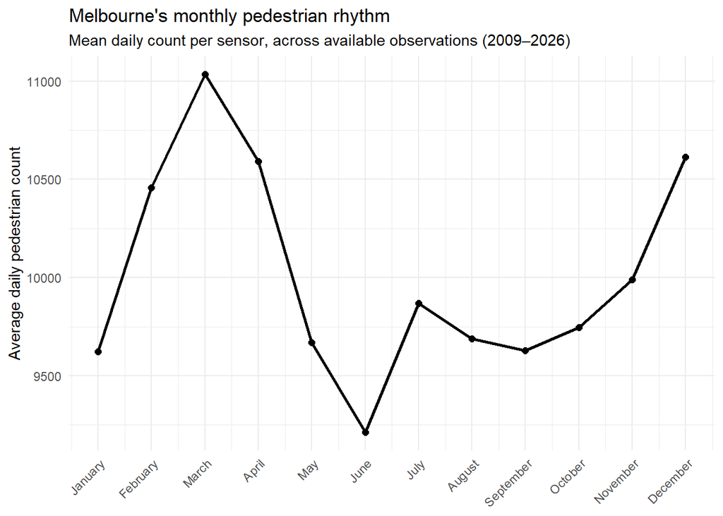

Figure 4: Mean daily recorded pedestrian counts by calendar month, using available observations during 2009–2026. Daily totals are averaged within each sensor and calendar month across available years, then averaged across sensors. Sensor-days with fewer than 20 recorded hours are excluded.

### 4.1.4 Seasonal pedestrian rhythm

Grouping the months into seasons provides a broader view of these recurring patterns. Figure 5 shows higher average activity in summer and autumn, with winter recording the lowest counts. This agrees with the broad seasonal pattern in Figure 4. However, the monthly calculation pools available dates within each sensor and calendar month, whereas the seasonal calculation averages within years before giving each available year equal weight. With changing sensor coverage and activity over time, these approaches can produce different overall levels, so their absolute counts should not be compared directly.

These differences are relevant to transport planning, public-space management and businesses that experience changes in pedestrian demand throughout the year. However, the results should be interpreted with some caution because sensor coverage changed over time and the dataset includes partial years.

Overall, the monthly and seasonal patterns provide context for understanding longer-term changes in pedestrian activity, particularly the disruption and recovery associated with COVID-19.

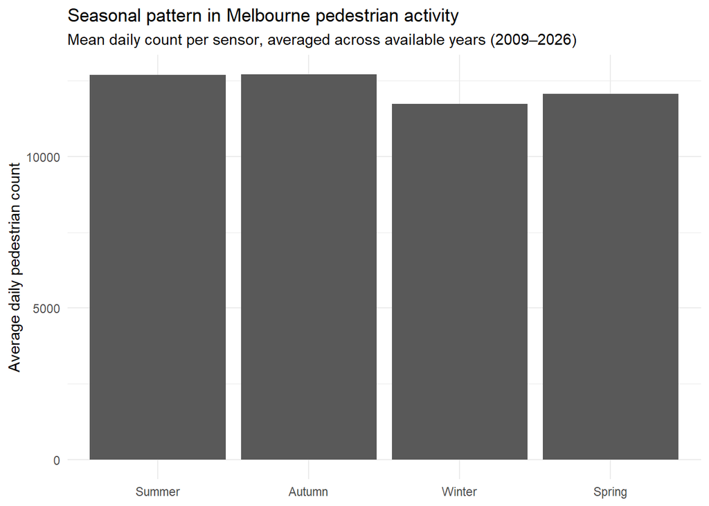

Figure 5: Mean daily recorded pedestrian counts by Australian season, 2009–2026. Sensor-level seasonal means are averaged across locations within each year, then across available years. Sensor-days with fewer than 20 recorded hours are excluded. This weighting differs from the monthly summary.

## 4.2 Long-term and COVID-19 changes

Melbourne’s pedestrian activity has undergone substantial changes over time, particularly during and after the COVID-19 pandemic. While the previous section examined recurring daily, weekly and seasonal patterns, this section investigates changes in the overall level of pedestrian activity and compares recent observations with conditions before the COVID-19 pandemic.

A key consideration is the expansion of Melbourne’s pedestrian sensor network. Comparing total pedestrian counts across different years may be misleading because the number and composition of reporting locations have changed over time.

To improve comparability, the analysis identifies 27 sensor locations that recorded observations on at least 300 days in each of the six selected years: 2017–2019 and 2023–2025. Median daily activity across these consistently monitored locations is then compared between the two periods.

This approach provides evidence of changes at selected monitoring locations while reducing the influence of sensor network expansion. A separate comparison of hourly activity patterns is also used to examine whether the timing of pedestrian movement has changed alongside overall volumes.

### 4.2.1 Long term pedestrian trends

Figure 6 shows substantial variation in pedestrian activity between 2009 and 2026. A particularly pronounced decline is visible during the COVID-19 period, followed by a recovery in subsequent years. Nevertheless, activity in the more recent period does not consistently reach the higher levels observed before the pandemic.

Consequently, this series provides a broad historical overview, while the comparison of 27 consistently monitored locations in the following section offers a more reliable assessment of changes between the selected pre-pandemic and recent periods.

[interactive chart not shown]

Figure 6: Monthly pedestrian activity among available members of the 27-location comparison panel, 2009–2026. Each sensor-month is summarised by its median recorded hourly count, and the plotted value is the median across eligible locations. Sensor-months require at least 15 observed dates; the number of reporting locations varies over time.

### 4.2.2 Pedestrian Activity Before and After COVID-19

Figure 7 compares recorded daily activity at the same 27 locations during 2017–2019 and 2023–2025. Within each period, all available location-day totals were pooled and their median—the middle value—was calculated. This median declined from approximately 10,091 to 7,211 recorded pedestrian passages, a reduction of 28.5%.

Using the same locations reduces the influence of the expanding sensor network. However, the result describes these selected locations rather than all pedestrian activity across Melbourne. Daily totals use the available hourly records, and differences in recording coverage and source conventions may affect the comparison, as discussed in Limitations.

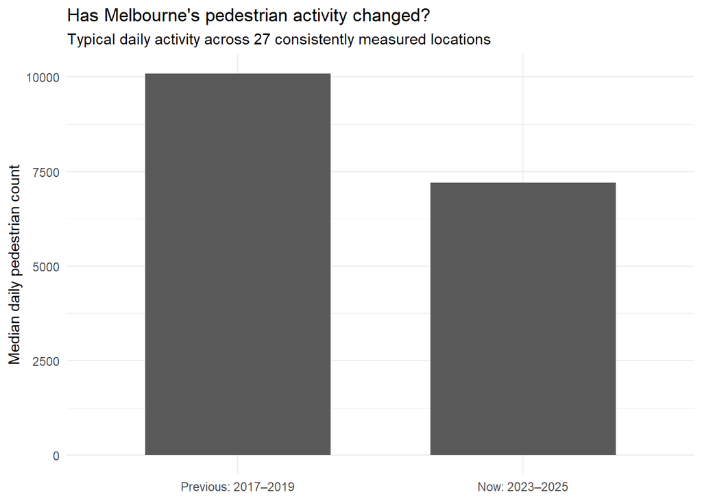

Figure 7: Pooled median recorded daily pedestrian counts across 27 selected monitoring locations during 2017–2019 and 2023–2025. Recorded hourly counts are summed for each sensor-day before calculating the median within each period. The comparison describes recorded activity at the selected locations.

### 4.2.3 Changes in Hourly Pedestrian Activity

Figure 8 shows that the general shape of Melbourne’s pedestrian activity remained recognisable between the two periods. Both 2017–2019 and 2023–2025 exhibit relatively low activity overnight, followed by increasing pedestrian movement during the morning and higher counts throughout the daytime.

However, the 2023–2025 profile remains below the pre-pandemic profile across much of the day, with particularly noticeable differences around the main daytime peaks. This suggests that although the timing of pedestrian movement remained broadly similar, its intensity declined at the selected monitoring locations.

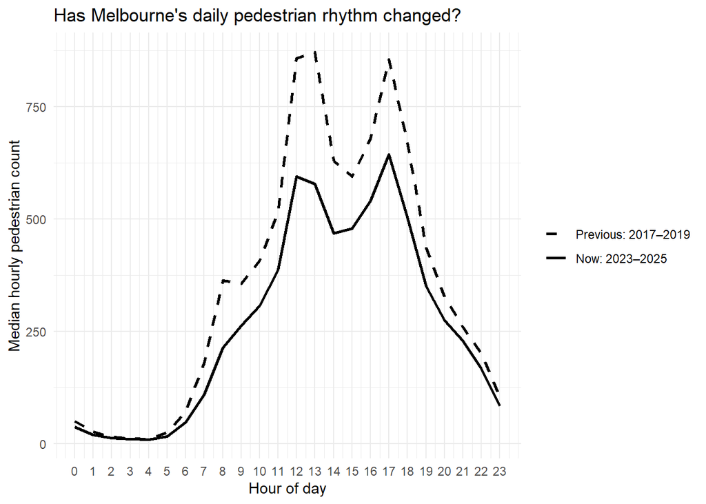

Figure 8: Median recorded pedestrian counts by hour across the 27 selected monitoring locations during 2017–2019 and 2023–2025. The dashed line represents 2017–2019 and the solid line represents 2023–2025. Values summarise available sensor-hour observations within each period.

## 4.3 Spatial differences in pedestrian activity

Pedestrian activity is not distributed evenly across Melbourne. Some locations experience consistently high pedestrian volumes, while others have different patterns depending on their surroundings and how people use the area.

An important consideration is the growth of the pedestrian sensor network over time. As more sensors were installed, the number of monitored locations increased, making direct comparisons of total counts across years less reliable. The following analysis therefore examines individual locations and uses coverage requirements to improve comparability.

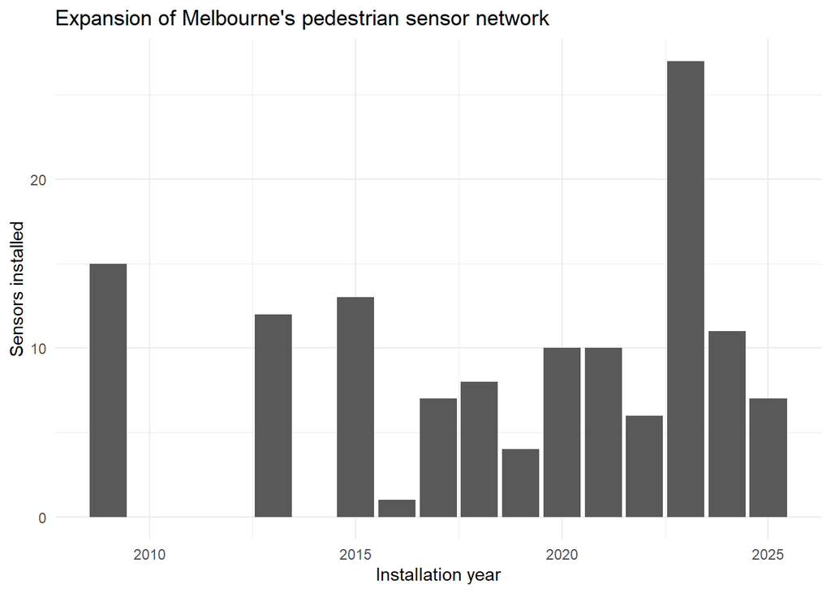

Figure 9: Number of pedestrian sensor installations by year, based on available installation dates in the sensor metadata. Installation counts describe network development and do not necessarily equal the number of locations actively reporting observations in each year.

Figure 9 illustrates the expansion of the sensor network through new installations. However, installation counts do not necessarily represent the number of sensors actively reporting pedestrian observations in each year, as individual sensors may experience interruptions or changes in operation.

[interactive chart not shown]

Figure 10: Spatial distribution of median daily recorded pedestrian counts at eligible monitoring locations in 2025. Larger symbols indicate higher counts. Locations require at least 292 sensor-days with 20 or more recorded hours and valid geographical coordinates.

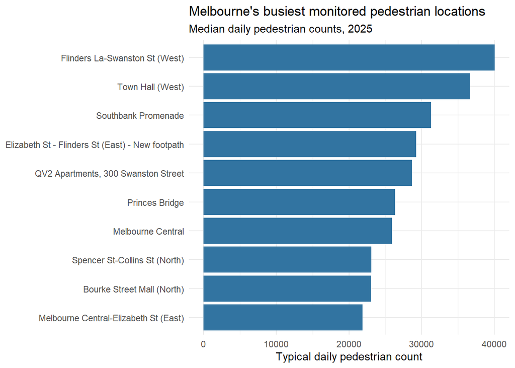

Figure 11: Ten highest median daily recorded pedestrian counts among eligible monitoring locations in 2025. Locations require at least 292 sensor-days with 20 or more recorded hours. Counts represent recorded passages at individual sensors rather than unique pedestrians or totals for entire precincts.

Figure 11 shows that pedestrian activity is concentrated around Melbourne’s major retail, transport and commercial areas. Flinders La–Swanston St (West) recorded the highest typical daily count at approximately 40,000 recorded pedestrians, followed by Town Hall (West) at approximately 36,000. Other busy monitored locations include Southbank Promenade, Elizabeth Street and the QV precinct.

Figure 10 illustrates the geographic distribution of pedestrian activity, while the top-10 ranking identifies the busiest monitored locations in 2025. These findings highlight the importance of Melbourne’s central pedestrian corridors.

However, the results represent pedestrian counts at individual sensor locations rather than total pedestrian activity across entire streets or precincts. Locations without sufficient observations during the selected period were excluded.

[interactive chart not shown]

Figure 12: Percentage change in pedestrian activity at 31 eligible monitoring locations, using available observations during 2024–2026 relative to corresponding calendar-month baselines from 2015–2019. Each location’s value is the median of its eligible monthly percentage changes. Colours distinguish increases from declines; the recent period includes a partial 2026.

Comparing recent activity with pre-COVID conditions reveals further differences between Melbourne’s monitored locations. For this analysis, average daily pedestrian counts were compared with the corresponding calendar-month baseline from 2015–2019. The recent recovery index was calculated using available observations from 2024–2026.

Figure 12 shows that recovery differs substantially between monitored locations. Webb Bridge recorded activity approximately 29.7% above its baseline, while Town Hall (West) was close to its earlier level at 0.4% above baseline. In contrast, Bourke Street Mall (South) remained approximately 42.5% below baseline. These differences show that the overall recovery summary conceals considerable variation between individual locations.

The comparison uses same-month baselines to account for recurring seasonal differences. However, it remains a descriptive analysis, and changes in surrounding land use, transport patterns or sensor conditions may also affect the results. The 2026 observations are incomplete, so the recent period should not be interpreted as three full calendar years.

### 4.3.1 Checking the Flinders Underpass Result

One location requiring closer examination was Flinders Underpass – Myki Barriers, where the recovery analysis (Figure 12) indicated a particularly large decline of approximately 72.6% compared with its pre-COVID baseline.

The sensor metadata records an upgrade in September 2021, raising the question of whether changes to the monitoring equipment could have affected the comparison. To investigate this, the monthly pedestrian counts were examined alongside the recorded upgrade date. A further sensitivity check compared the overall spatial results with and without this location.

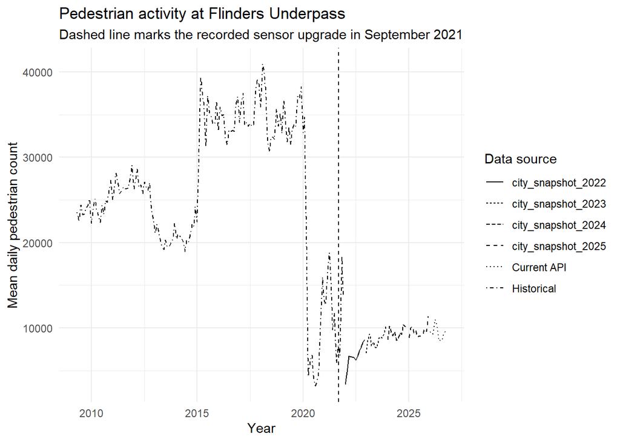

Figure 13: Monthly mean daily recorded pedestrian counts at Flinders Underpass–Myki Barriers. Daily totals retain dates with at least 20 recorded hours. Line styles distinguish data sources, and the vertical dashed line marks the sensor upgrade recorded on 8 September 2021.

Figure 13 shows that the decline had already begun before the recorded sensor upgrade in September 2021. The upgrade date therefore does not, by itself, explain the reduction. Changes in pedestrian movement and recording conditions may both affect this location’s results.

Sensitivity of the spatial recovery result to Flinders Underpass

| Comparison | Locations | Median change |
| --- | --- | --- |
| Including Flinders Underpass | 31 | -21% |
| Excluding Flinders Underpass | 30 | -20.5% |

Excluding Flinders Underpass changes the median spatial decline from 21.0% across 31 locations to 20.5% across 30 locations, a difference of only 0.5 percentage points. This indicates that the overall median result is relatively insensitive to this location, despite its unusually large individual decline.

### 4.3.2 K-means Clustering for pedestrian patterns

The analysis grouped 44 locations into two activity profiles using their weekday and weekend patterns during 2023–2025. The two-group solution provided the clearest separation among the alternatives tested, achieving the highest mean silhouette score of 0.442 (Table 2). Nine locations were assigned to Cluster 1 and 35 to Cluster 2. The preparation and grouping procedure is explained in Section 3.6.

The silhouette score measures how clearly the groups are separated, with higher values indicating clearer separation. Among the solutions tested, two groups produced the highest score. This supports using two groups for this comparison, although individual locations may still share characteristics across groups.

Table 2: Mean silhouette widths for K-means solutions with two to five clusters, using pedestrian activity profiles from 2023–2025.

| Number of clusters (K) | Mean silhouette width |
| --- | --- |
| 2 | 0.442 |
| 3 | 0.252 |
| 4 | 0.264 |
| 5 | 0.270 |

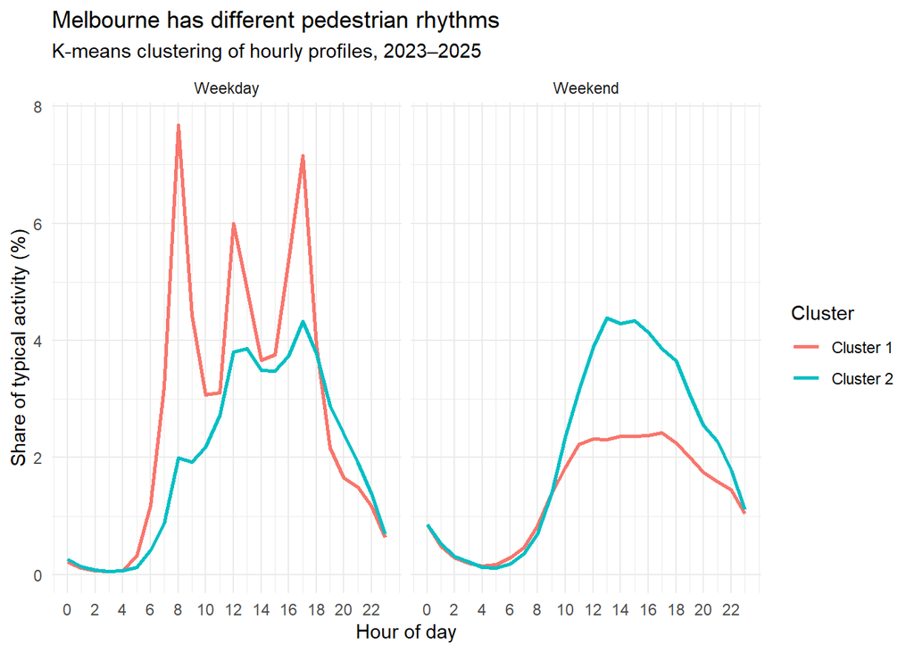

Figure 14: Typical weekday and weekend hourly profiles for two K-means clusters fitted to 44 eligible locations during 2023–2025. Each location’s hourly values are normalised jointly across its 48 weekday and weekend features. Lines show the median share at each hour within each cluster. Cluster 1 contains 9 locations and Cluster 2 contains 35.

[interactive chart not shown]

Figure 15: Geographical distribution of monitoring locations assigned to the two K-means clusters using their 2023–2025 weekday and weekend hourly profiles. Colours correspond to the cluster profiles shown in Figure 14.

Figure 14 shows two different activity profiles. Cluster 1, containing nine locations, has sharper weekday morning and late-afternoon peaks and lower relative weekend activity. Cluster 2, containing 35 locations, has broader daytime activity and relatively stronger weekend patterns. The distinction therefore concerns both when locations are busiest and how activity is distributed between weekdays and weekends.

Figure 15 shows where these two activity patterns occur across Melbourne. Viewing the geographic locations alongside their hourly profiles helps identify areas with similar movement patterns, even when they are not located next to one another.

Overall, the clustering analysis identifies two distinct patterns of pedestrian activity among the 44 selected locations. Together with the busiest-location rankings and spatial recovery analysis, it shows that Melbourne’s pedestrian network varies in both the intensity and timing of movement.

## 4.4 Outlier days, events and public holidays

Pedestrian activity occasionally departs substantially from its usual daily and seasonal patterns. While some dates record unusually high pedestrian volumes, others experience widespread declines. Examining these deviations helps identify periods when movement across Melbourne’s monitored locations differs from typical conditions.

This section investigates two types of unusual activity. First, pedestrian surges are identified and compared with permitted events recorded by the City of Melbourne. Second, unusually quiet days are examined alongside Victorian public holidays and weather conditions, particularly rainfall.

### 4.4.1 Unusual Pedestrian Surges: associations with permitted events

Daily pedestrian counts were compared with expected activity for the same weekday using the procedure described in Section 3.3. Uplift expresses the percentage increase above that reference: for example, 1,500 recorded passages compared with 1,000 expected passages represents a 50% uplift. The median uplift across reporting locations summarised each date.

The accompanying table and Figure 16 present the ten largest selected surge peaks with date-matched event permits during 2014–2018.

Largest pedestrian surges with date-matched event permits, 2014–2018

| Date | Median uplift | Largest sensor share | Matched permits | Example permit |
| --- | --- | --- | --- | --- |
| 22 Feb 2014 | 51.7% | 80% | 4 | 100mm Car Festival 2014 |
| 22 Feb 2015 | 32.2% | 63% | 1 | Melanoma March 2015 |
| 03 Nov 2014 | 27.7% | 55% | 1 | Emirates Melbourne Cup Parade |
| 20 Feb 2016 | 26.8% | 64% | 4 | 2016 Australian Tree ClimbingChampionships |
| 31 Dec 2017 | 26.3% | 60% | 1 | Vrr Fun Run - New Years Eve |
| 01 Oct 2015 | 22.8% | 55% | 1 | Festival Of Tabernacles |
| 17 Apr 2014 | 22.8% | 58% | 1 | Dave Matthews Band (SMMB) |
| 24 Apr 2016 | 22.1% | 54% | 2 | Anzac Day 2016 |
| 26 Jan 2014 | 21.1% | 50% | 5 | Australia Day 2014 |
| 14 Feb 2015 | 20.5% | 52% | 2 | Antipodes Festival 2015 |

“Largest sensor share” is the highest percentage of reporting sensors with activity at least 20% above expected during the surge episode. The date and median uplift refer to the episode’s peak date.

[interactive chart not shown]

Figure 16: Ten largest peak-day median pedestrian uplifts among selected surge episodes with date-matched event permits during 2014–2018. Uplift measures the percentage difference from the same-weekday reference activity defined in the methodology. Permit matches indicate temporal coincidence rather than confirmed event effects.

Returning to the opening example Figure 1, 22 February 2014 recorded the largest matched surge, with a median uplift of 51.7% across reporting sensors. This indicates that unusually high activity extended beyond the Flinders Street location. Four event permits matched this date, providing possible context for the increase, although date matching alone cannot establish which events contributed to the observed pattern.

### 4.4.2 Unusual pedestrian dips: associations with public holidays and rainfall

Apart from major events, pedestrian activity can also fall substantially below its usual level. This section examines whether unusually quiet days are associated with Victorian public holidays and weather conditions, particularly rainfall.

As in the event analysis, daily pedestrian activity was compared with nearby observations from the same sensor and day of the week. A substantial pedestrian dip was flagged when at least 10 sensors were reporting, the median change was −20% or lower, and at least 30% of reporting sensors recorded a decrease of 20% or more. These criteria help identify declines affecting several monitored locations rather than isolated changes at individual sensors.

Frequency of significant pedestrian dips by day type

| Day type | Total days | Substantial dip days | Dip rate |
| --- | --- | --- | --- |
| Other day | 1647 | 40 | 2.4% |
| Public holiday | 63 | 22 | 34.9% |

[interactive chart not shown]

Figure 17: Dates classified as substantial pedestrian dips within the eligible analysis periods: 2019, 2023–2025, and 1 January–6 September 2026. Each point shows the median percentage change from expected activity across reporting sensors; colour distinguishes Victorian public holidays from other days.

The comparison table shows that unusually quiet days occurred on 22 of 63 public holidays (34.9%), compared with 40 of 1,647 other dates (2.4%). This indicates that substantial declines were more common on public holidays within the dates analysed. Figure 17 illustrates when these declines occurred.

Christmas Day was among the dates associated with particularly large declines. This may reflect changes in everyday routines, including commuting, shopping and other activities that usually contribute to pedestrian movement in the city.

However, not every public holiday recorded a significant decrease. Some holidays may attract visitors or events that increase activity in particular areas. Therefore, these findings suggest an association between public holidays and pedestrian movement rather than a uniform effect across all locations.

Weather conditions on significant pedestrian dip days and other days

| Day category | Days | Median rainfall (mm) | Heavy rain days | Median max wind (km/h) |
| --- | --- | --- | --- | --- |
| Other day | 1607 | 0.2 | 4.2% | 19.8 |
| Substantial dip | 40 | 11.3 | 55% | 24.6 |

The weather comparison shows that unusually quiet pedestrian days tend to experience considerably more rainfall than other days. After excluding public holidays, the median rainfall was 11.3 mm on substantial dip days, compared with 0.2 mm on other days. Heavy rainfall of at least 10 mm was also more common on substantial dip days, occurring on approximately 55% of those dates compared with 4.2% of other days.

Wind speeds were also somewhat higher on substantial dip days. These differences suggest that unfavourable weather conditions may be associated with reduced pedestrian movement, although other factors may also contribute.

[interactive chart not shown]

Figure 18: Percentage of eligible non-holiday dates classified as substantial pedestrian dips, by daily rainfall category. The analysis covers 2019, 2023–2025, and 1 January–6 September 2026, comprising 1,647 dates. Categories are 0, above 0 to below 2, 2 to below 5, 5 to below 10, 10 to below 20, and at least 20 mm.

Figure 18 shows that substantial pedestrian dips were more frequent in the heavier-rain categories. Dip rates were 1.3% on dry days, 6.4% with 5–10 mm of rainfall, 17.4% with 10–20 mm, and 50.0% with at least 20 mm. However, the light-rain categories had lower dip rates than dry days, so the relationship was not uniformly increasing. The highest rate represents 10 dip dates among 20 eligible dates.

Overall, public holidays and rainfall both appear to be associated with unusually low pedestrian activity in Melbourne. Public holidays may change regular commuting and shopping patterns, while heavier rainfall may discourage outdoor movement.

# 5 Limitations

The findings should be interpreted alongside several limitations.

**Associations do not establish causes.** The analysis identifies relationships between pedestrian activity, events, holidays and weather. It cannot establish that these conditions caused the observed changes. Other factors, including transport disruptions, construction and school holidays, may also influence pedestrian movement.

**The monitored locations do not represent all of Melbourne.** Sensors are concentrated in the central business district and surrounding activity areas, and coverage has changed over time. Comparing the same 27 locations reduces the influence of network expansion, but the findings still describe selected monitored places. Similarly, the clustering results represent 44 locations with sufficiently consistent records.

**Recording conventions affect the 28.5% comparison.** Historical and City-supplied sources appear to represent zero-count hours differently. An absent hourly record therefore cannot always be interpreted as either zero activity or a recording gap. The comparison also pools recorded location-day totals, giving locations with more recorded days greater representation. The 28.5% decline should consequently be understood as a descriptive comparison of recorded activity at the selected locations, with its size dependent on coverage and calculation choices.

**Some historical records required reconstruction or source selection.** Comparing overlapping sources for 2022 identified 10,298 records with different counts, concentrated at Flinders Underpass. Separately, 12,240 records from September 2010 required reconstruction of their hour labels using record order. Although the repaired records passed consistency checks, their hourly patterns retain some uncertainty.

**Event matching and unusual-day classifications have limits.** Event permits were available only for 2014–2018, restricting the dates that could be matched. Multiple permits can also coincide with one date, so a matching permit does not establish which event contributed to a surge. Unusual days were identified using the stated percentage and sensor-coverage thresholds; different thresholds could identify different dates. The expected-activity calculation uses neighbouring available observations from the same weekday, which may be separated by gaps in the records.

**Weather and location groups simplify more complex conditions.** The weather analysis uses one daily weather series, which may not capture local conditions at every sensor. The clustering summarises weekday and weekend patterns during 2023–2025. Its two groups describe the selected locations during that period; individual locations may change their patterns over time.

# 6 Conclusion

Melbourne’s pedestrian activity follows recognisable daily, weekly and seasonal rhythms, while recorded volumes have changed over time. Across 27 selected monitoring locations, the pooled median of recorded daily counts was 28.5% lower during 2023–2025 than during 2017–2019. The hourly comparison nevertheless showed broadly similar timing, indicating lower recorded activity alongside a largely recognisable daily rhythm.

The spatial analysis showed that recovery varied considerably between locations. Clustering of 44 locations identified two profiles: one with sharper weekday peaks and another with broader daytime and relatively stronger weekend activity. Unusual activity also provided a different perspective on the city’s movement. Selected surges coincided with event permits, while public holidays and heavier rainfall were associated with more frequent substantial pedestrian dips.

These findings can inform staffing and service scheduling around monitored pedestrian corridors, provide context for event monitoring, and help identify locations requiring closer investigation. Their interpretation depends on sensor coverage, recording conventions and aggregation choices, and the selected locations do not represent every part of Melbourne.

Future work should clarify how zero activity and absent hourly records are represented across sources, assess sensitivity to coverage and anomaly thresholds, and extend event matching to more recent years. These steps would strengthen comparisons over time and improve understanding of how pedestrian activity differs across the city.

# AI Declaration

Generative AI tools, including ChatGPT, supported technical troubleshooting, interpretation of error messages, resolution of Git-related issues, and adjustments to presentation and formatting. They were also used to assist with refining report wording, figure captions, methodological explanations, and descriptions of analytical procedures. In some cases, the tools helped clarify technical concepts, suggest possible solutions, and improve the overall readability and structure of the written work. The project team independently evaluated all suggestions, checked the accuracy and relevance of the generated content, and made the final decisions regarding the analysis, interpretation of results, and presentation. The team retained full responsibility for verifying the work and for the final submitted content.

# Appendix: Supporting Data Tables

Table 3: Duplicate checks across the original pedestrian data sources.

| Source | Total records | Distinct records | Duplicate records |
| --- | --- | --- | --- |
| Current API | 1,628,822 | 1,628,822 | 0 |
| Historical | 4,562,230 | 4,562,230 | 0 |
| city_snapshot_2022 | 589,155 | 589,155 | 0 |
| city_snapshot_2023 | 656,632 | 656,632 | 0 |
| city_snapshot_2024 | 745,244 | 745,244 | 0 |
| city_snapshot_2025 | 815,447 | 815,447 | 0 |

Table 4: Variables in the consolidated pedestrian dataset.

| Variable | Description |
| --- | --- |
| location_id | Unique identifier for each sensor location |
| sensing_date | Date of the pedestrian observation |
| hourday | Hour of the day (0–23) |
| pedestrian_count | Number of pedestrians recorded during the hour |
| source | Dataset from which the observation originated |
| hour_repaired | Indicates whether the original hour label was reconstructed |
| year | Year of observation |
| month | Month of observation (1–12) |
| month_name | Name of the month |
| day_name | Day of the week |
| day_of_week | Day of the week (Monday = 1, Sunday = 7) |
| is_weekend | Indicates whether the observation occurred on a weekend |
| season | Australian season (Summer, Autumn, Winter or Spring) |

## References

Barrett, Tyson, Matt Dowle, and Arun Srinivasan. 2025. *Data.table: Extension of Data.frame*. https://CRAN.R-project.org/package=data.table.

Cheng, Joe, Barret Schloerke, Bhaskar Karambelkar, and Yihui Xie. 2024. *Leaflet: Create Interactive Web Maps with the JavaScript ’Leaflet’ Library*. https://CRAN.R-project.org/package=leaflet.

City of Melbourne. n.d.a. “Event Permits 2014–2018 Including Film Shoots, Photo Shoots, Weddings, Christmas Parties, Promotions, Fun Runs and Public Events.” Data set. https://data.melbourne.vic.gov.au/explore/dataset/event-permits-2014-2018-including-film-shoots-photo-shoots-weddings-christmas-pa/information/.

———. n.d.b. “Pedestrian Counting System - Sensor Locations.” https://data.melbourne.vic.gov.au/explore/dataset/pedestrian-counting-system-sensor-locations/.

———. n.d.c. “Pedestrian Counting System (Counts Per Hour).” https://data.melbourne.vic.gov.au/explore/dataset/pedestrian-counting-system-monthly-counts-per-hour/.

Department of Government Services. 2026. “Victorian Government - Important Dates API - Data.” DataVic dataset. https://discover.data.vic.gov.au/dataset/government-dates-api-data.

Firke, Sam. 2024. *Janitor: Simple Tools for Examining and Cleaning Dirty Data*. https://CRAN.R-project.org/package=janitor.

Grolemund, Garrett, and Hadley Wickham. 2011. “Dates and Times Made Easy with lubridate.” *Journal of Statistical Software* 40 (3): 1–25. https://www.jstatsoft.org/v40/i03/.

Hester, Jim, Hadley Wickham, and Gábor Csárdi. 2025. *Fs: Cross-Platform File System Operations Based on ’Libuv’*. https://CRAN.R-project.org/package=fs.

Maechler, Martin, Peter Rousseeuw, Anja Struyf, Mia Hubert, and Kurt Hornik. 2026. *Cluster: Cluster Analysis Basics and Extensions*. https://CRAN.R-project.org/package=cluster.

Müller, Kirill. 2025. *Here: A Simpler Way to Find Your Files*. https://CRAN.R-project.org/package=here.

Open-Meteo. n.d. “Historical Weather API.” https://open-meteo.com/en/docs/historical-weather-api.

Richardson, Neal, Ian Cook, Nic Crane, Dewey Dunnington, Romain François, Jonathan Keane, Bryce Mecum, et al. 2026. *Arrow: Integration to ’Apache’ ’Arrow’*. https://CRAN.R-project.org/package=arrow.

Sievert, Carson. 2020. *Interactive Web-Based Data Visualization with r, Plotly, and Shiny*. Chapman; Hall/CRC. https://plotly-r.com/.

Slowikowski, Kamil. 2026. *Ggrepel: Automatically Position Non-Overlapping Text Labels with ’Ggplot2’*. https://CRAN.R-project.org/package=ggrepel.

Vaughan, Davis. 2025. *Slider: Sliding Window Functions*. https://CRAN.R-project.org/package=slider.

Wickham, Hadley et al. 2019. “Welcome to the Tidyverse.” *Journal of Open Source Software* 4 (43): 1686. https://doi.org/10.21105/joss.01686.

Wickham, Hadley. 2025. *Httr2: Perform HTTP Requests and Process the Responses*. https://CRAN.R-project.org/package=httr2.

Zhu, Hao. 2024. *kableExtra: Construct Complex Table with ’Kable’ and Pipe Syntax*. https://CRAN.R-project.org/package=kableExtra.